title: “fINAL MODEL FOR CREDIT POLICY” author: “MEDHASWETA SEN” date: “2022-12-10” output: html_document —

```r
loadPkg("ggplot2")
```

# LogRegcredit.policy Dataset (Admissions data)

## Initialize

```r
# credit.policy <- data.frame(read.csv("LogRegcredit.policy.csv"))
df <- read.csv("loan_data.csv")
head(df)
summary(df)
str(df)
sum(is.na(df))
df$credit.policy=as.numeric(df$credit.policy)
```

```r
xkablesummary(df)
```

Table: Statistics summary.

|  | credit.policy | purpose | int.rate | installment | log.annual.inc | dti | fico | days.with.cr.line | revol.bal | revol.util | inq.last.6mths | delinq.2yrs | pub.rec | not.fully.paid |
| --- | --- | --- | --- | --- | --- | --- | --- | --- | --- | --- | --- | --- | --- | --- |
| Min | Min. :0.000 | Length:9578 | Min. :0.060 | Min. : 16 | Min. : 7.55 | Min. : 0.00 | Min. :612 | Min. : 179 | Min. : 0 | Min. : 0.0 | Min. : 0.0 | Min. : 0.00 | Min. :0.00 | Min. :0.00 |
| Q1 | 1st Qu.:1.000 | Class :character | 1st Qu.:0.104 | 1st Qu.:164 | 1st Qu.:10.56 | 1st Qu.: 7.21 | 1st Qu.:682 | 1st Qu.: 2820 | 1st Qu.: 3187 | 1st Qu.: 22.6 | 1st Qu.: 0.0 | 1st Qu.: 0.00 | 1st Qu.:0.00 | 1st Qu.:0.00 |
| Median | Median :1.000 | Mode :character | Median :0.122 | Median :269 | Median :10.93 | Median :12.66 | Median :707 | Median : 4140 | Median : 8596 | Median : 46.3 | Median : 1.0 | Median : 0.00 | Median :0.00 | Median :0.00 |
| Mean | Mean :0.805 | NA | Mean :0.123 | Mean :319 | Mean :10.93 | Mean :12.61 | Mean :711 | Mean : 4561 | Mean : 16914 | Mean : 46.8 | Mean : 1.6 | Mean : 0.16 | Mean :0.06 | Mean :0.16 |
| Q3 | 3rd Qu.:1.000 | NA | 3rd Qu.:0.141 | 3rd Qu.:433 | 3rd Qu.:11.29 | 3rd Qu.:17.95 | 3rd Qu.:737 | 3rd Qu.: 5730 | 3rd Qu.: 18250 | 3rd Qu.: 70.9 | 3rd Qu.: 2.0 | 3rd Qu.: 0.00 | 3rd Qu.:0.00 | 3rd Qu.:0.00 |
| Max | Max. :1.000 | NA | Max. :0.216 | Max. :940 | Max. :14.53 | Max. :29.96 | Max. :827 | Max. :17640 | Max. :1207359 | Max. :119.0 | Max. :33.0 | Max. :13.00 | Max. :5.00 | Max. :1.00 |

We can also find sd or other statistics of the variables using the `sapply()` function, and display as a table.

```r
# find  sd for all columns, using sapply
varSD = sapply(df, sd)
varSD
```

```r
xkabledply(as.table(varSD), title = "The sd for each variable in credit.policy", wide = TRUE)
```

The sd for each variable in credit.policy

| credit.policy | purpose | int.rate | installment | log.annual.inc | dti | fico | days.with.cr.line | revol.bal | revol.util | inq.last.6mths | delinq.2yrs | pub.rec | not.fully.paid |
| --- | --- | --- | --- | --- | --- | --- | --- | --- | --- | --- | --- | --- | --- |
| 0.396 | NA | 0.0268 | 207 | 0.615 | 6.88 | 38 | 2497 | 33756 | 29 | 2.2 | 0.546 | 0.262 | 0.367 |

## Effects on Admission by purpose

To study the effects on admission by the factor purpose (credit.policy and purpose are both categorical variables), wee can create two-way contingency table of the outcome and predictors, and make sure there are no cells of zero frequencies.  
*A contingency table, sometimes called a two-way frequency table, is a tabular mechanism with at least two rows and two columns used in statistics to present categorical data in terms of frequency counts.

```r
credit.policypurposetable = xtabs(~ credit.policy + purpose, data = df)
credit.policypurposetable
```

## feature selection

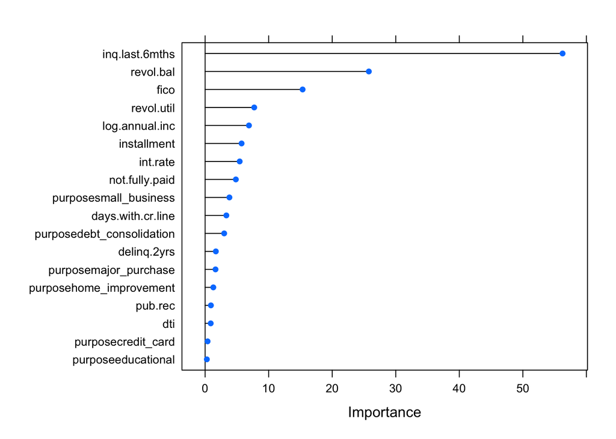

```r
set.seed(7)
# load the library
library(mlbench)
library(caret)
# load the dataset
# prepare training scheme
control <- trainControl(method="repeatedcv", number=10, repeats=3)
# train the model
class(df$credit.policy)
model <- train(credit.policy~., data=df, method="glm", preProcess="scale", trControl=control)
# estimate variable importance
importance <- varImp(model, scale=FALSE)
# summarize importance
print(importance)
# plot importance
plot(importance)
```

```r
#names(getModelInfo())
```

## Logistic Regression Model

```r
df$credit.policy <- factor(df$credit.policy)
str(df)
df$purpose <- factor(df$purpose)
#str(credit.policy)
credit.policyLogit <- glm(credit.policy ~ . , data = df, binomial(link = "logit") )
```

We can see the summary of the logit model here:

```r
summary(credit.policyLogit)
```

```r
xkabledply(credit.policyLogit, title = "Logistic Regression :")
```

Logistic Regression :

|  | Estimate | Std. Error | z value | Pr(>\|z\|) |
| --- | --- | --- | --- | --- |
| (Intercept) | -37.3822 | 1.9549 | -19.122 | 0.0000 |
| purposecredit_card | 0.0775 | 0.1328 | 0.583 | 0.5598 |
| purposedebt_consolidation | 0.2909 | 0.1008 | 2.887 | 0.0039 |
| purposeeducational | 0.1763 | 0.2006 | 0.879 | 0.3795 |
| purposehome_improvement | 0.2907 | 0.1788 | 1.626 | 0.1040 |
| purposemajor_purchase | 0.2999 | 0.2093 | 1.433 | 0.1519 |
| purposesmall_business | 0.3499 | 0.1818 | 1.925 | 0.0542 |
| int.rate | 2.0886 | 2.4278 | 0.860 | 0.3896 |
| installment | 0.0008 | 0.0003 | 3.129 | 0.0018 |
| log.annual.inc | 0.7887 | 0.0799 | 9.872 | 0.0000 |
| dti | 0.0039 | 0.0061 | 0.645 | 0.5192 |
| fico | 0.0450 | 0.0022 | 20.548 | 0.0000 |
| days.with.cr.line | 0.0001 | 0.0000 | 6.665 | 0.0000 |
| revol.bal | 0.0000 | 0.0000 | -23.332 | 0.0000 |
| revol.util | 0.0087 | 0.0017 | 5.242 | 0.0000 |
| inq.last.6mths | -0.9784 | 0.0266 | -36.851 | 0.0000 |
| delinq.2yrs | -0.1511 | 0.0619 | -2.442 | 0.0146 |
| pub.rec | -0.0412 | 0.1357 | -0.304 | 0.7612 |
| not.fully.paid | -0.2578 | 0.0941 | -2.739 | 0.0062 |

Before moving on, let us look at the model object `credit.policyLogit` a little deeper. The fitted values can be found from `credit.policyLogit$fitted.values`. And the first fitted value is 0.997. This is the probability of being credit.policyted for data point #1. Compare to the value from `predict(credit.policyLogit)` to be 5.952.

The `predict()` function gives us the logit value. You can exponentiate to get the odds ratio p/q as 384.348. And finally, we can find p from p/q, and indeed it is confirmed to be 0.997.

The easier way to get that is simply use `predict(credit.policyLogit, type = c("response"))[1]` = 0.997. The `predict()` function will also allow you to find model prediction with unseen/untrained data points where `fitted.values` do not give.

```r
p_fitted = credit.policyLogit$fitted.values[1] # this is the model predicated value p-hat for the first data row (not the actual data point p)
```

This is stored in the model as the fitted value for the probability `p` of the first data point. Since the actual data point is a 0/1 True/False value, it is not easy to directly compare them unless we use a cutoff value (default as 0.5) to convert the probability `p` to 0/1.

```r
# This gives you the predicted values of the data points inside the model.
predict(credit.policyLogit)  # the is from the model, which gives you the value for logit(p) or ln(p/q)
```

### Confidence Intervals

We can easily determine the confidence intervals of each coefficient with these two slightly different ways:

```r
## CIs using profiled log-likelihood
# confint(credit.policyLogit)
xkabledply( confint(credit.policyLogit), title = "CIs using profiled log-likelihood" )
```

CIs using profiled log-likelihood

|  | 2.5 % | 97.5 % |
| --- | --- | --- |
| (Intercept) | -41.2462 | -33.5814 |
| purposecredit_card | -0.1819 | 0.3389 |
| purposedebt_consolidation | 0.0931 | 0.4882 |
| purposeeducational | -0.2122 | 0.5749 |
| purposehome_improvement | -0.0562 | 0.6451 |
| purposemajor_purchase | -0.1036 | 0.7179 |
| purposesmall_business | -0.0028 | 0.7100 |
| int.rate | -2.6658 | 6.8538 |
| installment | 0.0003 | 0.0013 |
| log.annual.inc | 0.6328 | 0.9460 |
| dti | -0.0081 | 0.0159 |
| fico | 0.0408 | 0.0494 |
| days.with.cr.line | 0.0001 | 0.0002 |
| revol.bal | 0.0000 | 0.0000 |
| revol.util | 0.0055 | 0.0120 |
| inq.last.6mths | -1.0312 | -0.9271 |
| delinq.2yrs | -0.2711 | -0.0281 |
| pub.rec | -0.3027 | 0.2293 |
| not.fully.paid | -0.4415 | -0.0725 |

```r
## CIs using standard errors
# confint.default(credit.policyLogit)
xkabledply( confint.default(credit.policyLogit), title = "CIs using standard errors" )
```

CIs using standard errors

|  | 2.5 % | 97.5 % |
| --- | --- | --- |
| (Intercept) | -41.2137 | -33.5506 |
| purposecredit_card | -0.1829 | 0.3378 |
| purposedebt_consolidation | 0.0934 | 0.4883 |
| purposeeducational | -0.2169 | 0.5696 |
| purposehome_improvement | -0.0597 | 0.6412 |
| purposemajor_purchase | -0.1104 | 0.7102 |
| purposesmall_business | -0.0063 | 0.7061 |
| int.rate | -2.6698 | 6.8469 |
| installment | 0.0003 | 0.0013 |
| log.annual.inc | 0.6321 | 0.9452 |
| dti | -0.0081 | 0.0159 |
| fico | 0.0407 | 0.0493 |
| days.with.cr.line | 0.0001 | 0.0002 |
| revol.bal | 0.0000 | 0.0000 |
| revol.util | 0.0055 | 0.0120 |
| inq.last.6mths | -1.0305 | -0.9264 |
| delinq.2yrs | -0.2723 | -0.0298 |
| pub.rec | -0.3071 | 0.2247 |
| not.fully.paid | -0.4422 | -0.0733 |

### Model evaluation

#### Confusion matrix

This is just one of the many libraries you can find the confusion matrix. It is easy to use, but not very powerful, lacking ability to choose cutoff value, and it does not give you all the metrics like accuracy, precision, recall, sensitivity, f1 score etc. Nonetheless, it’s handy.

```r
loadPkg("regclass")
# confusion_matrix(credit.policyLogit)
xkabledply( confusion_matrix(credit.policyLogit), title = "Confusion matrix from Logit Model" )
```

Confusion matrix from Logit Model

|  | Predicted 0 | Predicted 1 | Total |
| --- | --- | --- | --- |
| Actual 0 | 1219 | 649 | 1868 |
| Actual 1 | 267 | 7443 | 7710 |
| Total | 1486 | 8092 | 9578 |

```r
unloadPkg("regclass")
```

#### Receiver-Operator-Characteristic (ROC) curve and Area-Under-Curve (AUC)

Receiver-Operator-Characteristic (ROC) curve and Area-Under-Curve (AUC) measures the true positive rate (or sensitivity) against the false positive rate (or specificity). The area-under-curve is always between 0.5 and 1. Values higher than 0.8 is considered good model fit.

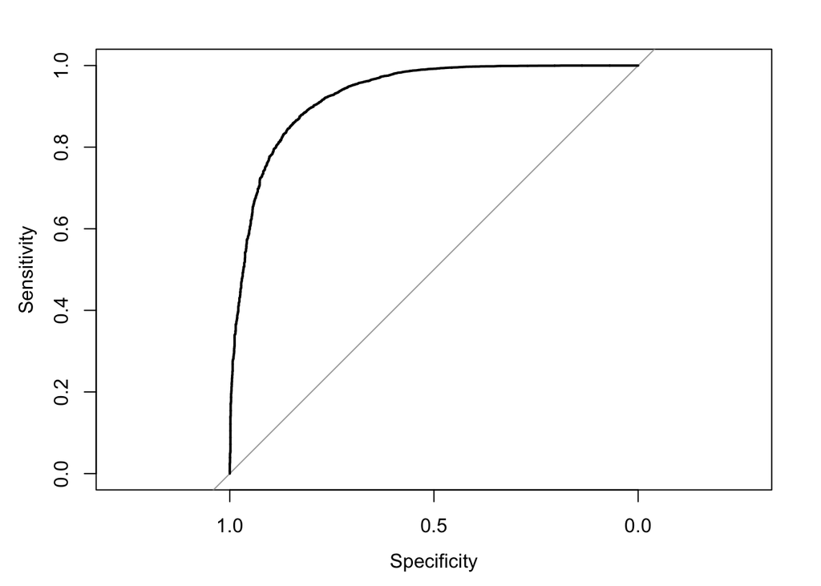

```r
loadPkg("pROC") # receiver operating characteristic curve, gives the diagnostic ability of a binary classifier system as its discrimination threshold is varied. The curve is on sensitivity/recall/true-positive-rate vs false_alarm/false-positive-rate/fall-out.
prob=predict(credit.policyLogit, type = "response" )
df$prob <- NA
df$prob=prob
h <- roc(credit.policy~prob, data=df)
auc(h) # area-under-curve prefer 0.8 or higher.
plot(h)
```

```r
# unloadPkg("pROC")
head(df)
```

#### McFadden

McFadden is another evaluation tool we can use on logit regressions. This is part of what is called pseudo-R-squared values for evaluation tests. We can calculate the value directly from its definition if we so choose to.

```r
credit.policyNullLogit <- glm(credit.policy ~ 1, data = df, family = "binomial")
mcFadden = 1 - logLik(credit.policyLogit)/logLik(credit.policyNullLogit)
mcFadden
```

Or we can use other libraries. The `pscl` (Political Science Computational Lab) library has the function `pR2()` (pseudo-$R^2$) will do the trick.

```r
loadPkg("pscl") # use pR2( ) function to calculate McFadden statistics for model eval
credit.policyLogitpr2 = pR2(credit.policyLogit)
credit.policyLogitpr2
unloadPkg("pscl")
```

With the McFadden value of 0.511, which is analogous to the coefficient of determination $R^2$, only about 51% of the variations in y is explained by the explanatory variables in the model.

A major weakness of the overall model is likely from the small dataset sample size of 9578. We expect a much higher number of observations will increase the sensitivity of the model.

#### Hosmer and Lemeshow test

The Hosmer and Lemeshow Goodness of Fit test can be used to evaluate logistic regression fit.

```r
loadPkg("ResourceSelection") # function hoslem.test( ) for logit model evaluation
```

```r
credit.policyLogitHoslem = hoslem.test(df$credit.policy, fitted(credit.policyLogit)) # Hosmer and Lemeshow test, a chi-squared test
```

The result is shown here:

```r
credit.policyLogitHoslem
```

```
##
##  Hosmer and Lemeshow goodness of fit (GOF) test
##
## data:  df$credit.policy, fitted(credit.policyLogit)
## X-squared = 9578, df = 8, p-value <2e-16
```

```r
# Have not found a good way to display it.
```